# Coursera Practical Machine Learning Course Project

nsen

July 3, 2016

## Overview

The goal of this anaysis is to use data from accelerometers on the belt, forearm, arm, and dumbell of 6 participants to build a model that that can predict, based on aquired data, the manner in which they did the exercise. They were asked to perform barbell lifts correctly and incorrectly in 5 different ways.

```r
if(!require(caret)) install.packages("caret", dependencies = TRUE)
require(caret)

if(!require(data.table)) install.packages("data.table")
require(data.table)

if(!require(lattice)) install.packages("lattice")
require(lattice)
```

## Methodology

- Model Data Preparation
- Feature Selection
- Predictive Model Construction
- Model Evaluation
- Prediction

## Model Data Preparation

The data for this project come from this source: http://groupware.les.inf.puc-rio.br/har.

```r
dtTrain <- fread("https://d396qusza40orc.cloudfront.net/predmachlearn/pml-training.csv")
dtTest <- fread("https://d396qusza40orc.cloudfront.net/predmachlearn/pml-testing.csv")
```

Split trainng and test data for cross validation. Will use 60% of the data will be used for training, 40% for testing.

```r
set.seed(12345)

train <- createDataPartition(dtTrain$classe, p=0.6, list=FALSE)

#Split into Training Data and Test data
dtTrainData <- dtTrain[train]
dtTestData <- dtTrain[-train]

#Set classe variable as factor to optimize performance
dtTrainData$classe <- factor(dtTrainData$classe)
dtTestData$classe <- factor(dtTestData$classe)
```

## Feature Selection

In order to optimize model performance, we eliminate the near zero variance parameters. In addition we also remove parameters that have more than 90% NAs and the ones that do not seem relevant based on description and values.

```r
#Remove variables which have Near Zero variance
variables.nz <- nearZeroVar(dtTrainData)
dtTrainData <- as.data.frame(dtTrainData)[,-variables.nz]
dtTestData <- as.data.frame(dtTestData)[,-variables.nz]

# Remove variables where more than 90% of the values are missing
variables.na <- sapply(dtTrainData, function(x) mean(is.na(x))>0.90)
dtTrainData <- as.data.frame(dtTrainData)[,variables.na == F]
dtTestData <- as.data.frame(dtTestData)[,variables.na == F]

#Remove first 6 variables as they do not seem to be relevant to the predition (using my own judgement here)
dtTrainData <- dtTrainData[,-c(1:6)]
dtTestData <- dtTestData[,-c(1:6)]
```

## Predicive Model Construction

Random Forrest (rf) model will be used utilizing Cross Validation. Sample Training data set will be used to train the model. 3-fold cross validation will be applied.

```r
# Set up Cross Validation
cv.con <- trainControl(method="cv", number = 3, verboseIter = TRUE)

# Train Random Forrest model
mod.rf <- train(classe ~., data=dtTrainData, method="rf", trControl=cv.con)

# Save the model
save(mod.rf, file='./mod_rf.RData')
```

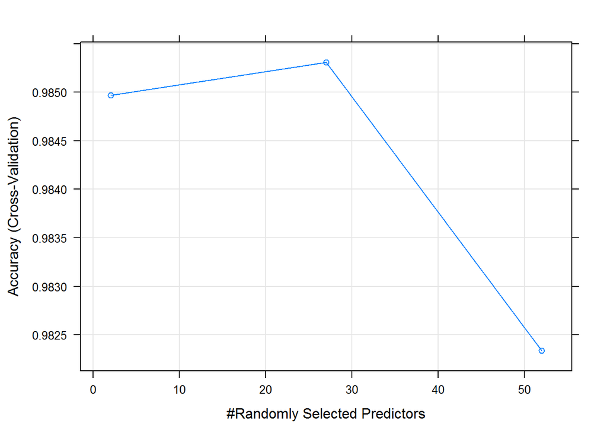

```r
plot(mod.rf)
```

```r
# display final model and examine parameters
mod.rf$finalModel
```

```
##
## Call:
##  randomForest(x = x, y = y, mtry = param$mtry)
##                Type of random forest: classification
##                      Number of trees: 500
## No. of variables tried at each split: 27
##
##         OOB estimate of  error rate: 0.92%
## Confusion matrix:
##      A    B    C    D    E class.error
## A 3341    5    0    0    2 0.002090800
## B   20 2247   11    0    1 0.014041246
## C    1    9 2033   11    0 0.010223953
## D    0    0   29 1897    4 0.017098446
## E    0    1    5    9 2150 0.006928406
```

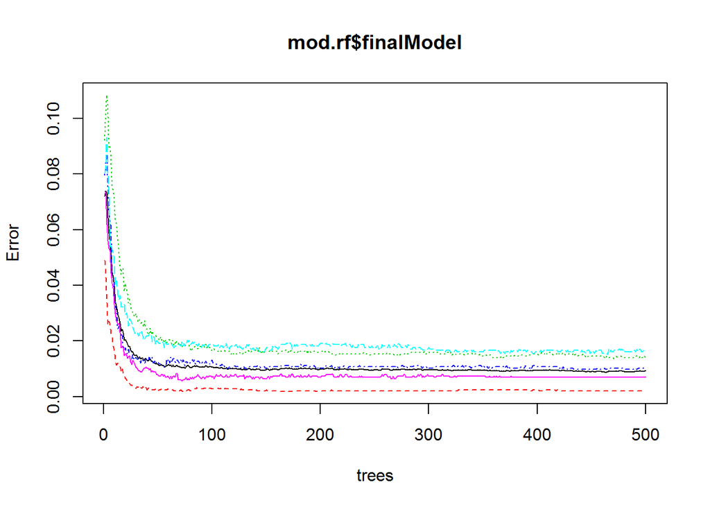

```r
plot(mod.rf$finalModel)
```

Model used 500 trees and tried 27 variables at each split.

## Model Evaluation

Determining Out of Sample Error and Model accuracy.

```r
mod.rf.pred <- predict(mod.rf, newdata=dtTestData)
mod.rf.cm <- confusionMatrix(mod.rf.pred, dtTestData$classe)

mod.rf.cm
```

```
## Confusion Matrix and Statistics
##
##           Reference
## Prediction    A    B    C    D    E
##          A 2229   10    0    0    0
##          B    3 1501    6    0    1
##          C    0    7 1358   19    3
##          D    0    0    4 1263    5
##          E    0    0    0    4 1433
##
## Overall Statistics
##
##                Accuracy : 0.9921
##                  95% CI : (0.9899, 0.9939)
##     No Information Rate : 0.2845
##     P-Value [Acc > NIR] : < 2.2e-16
##
##                   Kappa : 0.99
##  Mcnemar's Test P-Value : NA
##
## Statistics by Class:
##
##                      Class: A Class: B Class: C Class: D Class: E
## Sensitivity            0.9987   0.9888   0.9927   0.9821   0.9938
## Specificity            0.9982   0.9984   0.9955   0.9986   0.9994
## Pos Pred Value         0.9955   0.9934   0.9791   0.9929   0.9972
## Neg Pred Value         0.9995   0.9973   0.9985   0.9965   0.9986
## Prevalence             0.2845   0.1935   0.1744   0.1639   0.1838
## Detection Rate         0.2841   0.1913   0.1731   0.1610   0.1826
## Detection Prevalence   0.2854   0.1926   0.1768   0.1621   0.1832
## Balanced Accuracy      0.9984   0.9936   0.9941   0.9904   0.9966
```

We have 99% accuracy at 95% CI. We can conlude that Random Forrest is a good prediction model and we will use it for that purpose.

## Prediction

Making preditions on the originally supplied test data.

```r
# Use Random Forrest Model to predict
mod.rf.pred <- predict(mod.rf, dtTest)

# Results
mod.rf.pred
```

```
##  [1] B A B A A E D B A A B C B A E E A B B B
## Levels: A B C D E
```